# TP05 — Apprentissage non supervisé

## Réduction de dimension et clustering

**Dans ce TP, vous devrez non seulement exécuter des algorithmes, mais aussi justifier les choix de prétraitement, interpréter les résultats et discuter les limites des méthodes.**

## Objectifs

À l'issue du TP, vous devrez être capable de :

- expliquer les objectifs de l'apprentissage non supervisé ;
- distinguer une méthode linéaire (ACP/PCA) de méthodes non linéaires (t-SNE, UMAP) ;
- implémenter une ACP « à la main » avec `pandas` et `numpy` ;
- comparer une implémentation manuelle à celle de `scikit-learn` ;
- appliquer k-means et évaluer un clustering avec des métriques internes et externes ;
- analyser l'influence de la standardisation, des hyperparamètres et de l'initialisation;
- être capable d'utiliser la [documentation](https://scikit-learn.org/stable/) `scikit-learn`.

## 1. Rappels de cours — apprentissage non supervisé

L'apprentissage non supervisé cherche à extraire une structure à partir des seules variables d'entrée, sans cible à prédire. Il permet notamment de répondre aux questions suivantes :

- quelles observations se ressemblent ?
- quelles variables sont redondantes ?
- peut-on représenter les données dans un espace plus petit ?
- certains points sont-ils atypiques ?

Dans ce TP, nous étudions deux familles de méthodes :

1. **Réduction de dimension** : ACP/PCA, t-SNE et UMAP ;
2. **Clustering** : k-means.

Une réduction de dimension peut servir à visualiser, compresser, débruiter ou préparer les données avant un autre algorithme. Attention : une projection visuellement convaincante ne garantit pas qu'elle préserve toutes les propriétés géométriques du jeu de données.

```python
# Décommentez uniquement si les bibliothèques ne sont pas installées.
# %pip install -q scikit-learn umap-learn
# %pip install pandas matplotlib
```

[output not shown]

```python
import numpy as np
import pandas as pd
import matplotlib.pyplot as plt

from sklearn.datasets import load_wine, load_digits
from sklearn.preprocessing import StandardScaler
from sklearn.decomposition import PCA
from sklearn.manifold import TSNE
from sklearn.cluster import KMeans
from sklearn.metrics import silhouette_score, adjusted_rand_score, normalized_mutual_info_score

RANDOM_STATE = 42
np.random.seed(RANDOM_STATE)
```

# Partie I — Réduction de dimension

## 2. Analyse en composantes principales (ACP/PCA)

Soit une matrice de données $X \in \mathbb{R}^{n \times d}$, où les lignes sont les observations et les colonnes les variables.

L'ACP recherche des directions orthogonales maximisant successivement la variance projetée. Pour des données centrées $X_c$, la matrice de covariance peut s'écrire :

$$ \Sigma = \frac{1}{n-1}X_c^\top X_c. $$

Les vecteurs propres de $\Sigma$ définissent les axes principaux. Les valeurs propres associées mesurent la variance portée par ces axes. La projection sur les $k$ premiers axes est :

$$ Z = X_c W_k, $$

où $W_k$ contient les $k$ vecteurs propres associés aux plus grandes valeurs propres.

### Centrer ou standardiser ?

L'ACP de `scikit-learn` centre automatiquement les variables, mais ne les réduit pas. La standardisation est généralement nécessaire lorsque les variables sont exprimées dans des unités différentes ou ont des ordres de grandeur très différents. Elle n'est toutefois pas neutre : elle donne la même variance initiale à chaque variable, y compris à une variable éventuellement très bruitée.

### Exercice 1 — Chargement et exploration du jeu de données Wine

1. Chargez le jeu de données `wine` avec `load_wine(as_frame=True)`.
2. Créez un `DataFrame` contenant les variables et une série contenant les classes.
3. Affichez les dimensions, les types, les statistiques descriptives et les éventuelles valeurs manquantes.
4. Comparez les ordres de grandeur et les variances des variables.
5. Expliquez pourquoi une ACP standardisée semble pertinente (ou non pertinente) ici.

```python
wine = load_wine(as_frame=True)
X = wine.data.copy()
y = wine.target.copy()

print(f"Dimensions de X : {X.shape}")
print(f"Dimensions de y : {y.shape}")

print("\nTypes des variables :")
display(X.dtypes.to_frame("dtype").T)

print("\nStatistiques descriptives :")
display(X.describe().T)

print("\nValeurs manquantes par variable :")
display(X.isna().sum().to_frame("nb_valeurs_manquantes").T)

comparison = pd.DataFrame({
    "moyenne": X.mean(),
    "ecart_type": X.std(ddof=1),
    "variance": X.var(ddof=1),
    "minimum": X.min(),
    "maximum": X.max(),
})
print("\nComparaison des ordres de grandeur et des variances :")
display(comparison.sort_values("variance", ascending=False))

print(
    "\nConclusion : les variables ont des unités et des échelles très différentes. "
    "Une ACP standardisée est donc pertinente afin d'éviter que les variables "
    "de grande amplitude dominent artificiellement les premières composantes."
)
```

```
Dimensions de X : (178, 13)
Dimensions de y : (178,)

Types des variables :
```

|  | alcohol | malic_acid | ash | alcalinity_of_ash | magnesium | total_phenols | flavanoids | nonflavanoid_phenols | proanthocyanins | color_intensity | hue | od280/od315_of_diluted_wines | proline |
| --- | --- | --- | --- | --- | --- | --- | --- | --- | --- | --- | --- | --- | --- |
| dtype | float64 | float64 | float64 | float64 | float64 | float64 | float64 | float64 | float64 | float64 | float64 | float64 | float64 |

```
Statistiques descriptives :
```

|  | count | mean | std | min | 25% | 50% | 75% | max |
| --- | --- | --- | --- | --- | --- | --- | --- | --- |
| alcohol | 178.0 | 13.000618 | 0.811827 | 11.03 | 12.3625 | 13.050 | 13.6775 | 14.83 |
| malic_acid | 178.0 | 2.336348 | 1.117146 | 0.74 | 1.6025 | 1.865 | 3.0825 | 5.80 |
| ash | 178.0 | 2.366517 | 0.274344 | 1.36 | 2.2100 | 2.360 | 2.5575 | 3.23 |
| alcalinity_of_ash | 178.0 | 19.494944 | 3.339564 | 10.60 | 17.2000 | 19.500 | 21.5000 | 30.00 |
| magnesium | 178.0 | 99.741573 | 14.282484 | 70.00 | 88.0000 | 98.000 | 107.0000 | 162.00 |
| total_phenols | 178.0 | 2.295112 | 0.625851 | 0.98 | 1.7425 | 2.355 | 2.8000 | 3.88 |
| flavanoids | 178.0 | 2.029270 | 0.998859 | 0.34 | 1.2050 | 2.135 | 2.8750 | 5.08 |
| nonflavanoid_phenols | 178.0 | 0.361854 | 0.124453 | 0.13 | 0.2700 | 0.340 | 0.4375 | 0.66 |
| proanthocyanins | 178.0 | 1.590899 | 0.572359 | 0.41 | 1.2500 | 1.555 | 1.9500 | 3.58 |
| color_intensity | 178.0 | 5.058090 | 2.318286 | 1.28 | 3.2200 | 4.690 | 6.2000 | 13.00 |
| hue | 178.0 | 0.957449 | 0.228572 | 0.48 | 0.7825 | 0.965 | 1.1200 | 1.71 |
| od280/od315_of_diluted_wines | 178.0 | 2.611685 | 0.709990 | 1.27 | 1.9375 | 2.780 | 3.1700 | 4.00 |
| proline | 178.0 | 746.893258 | 314.907474 | 278.00 | 500.5000 | 673.500 | 985.0000 | 1680.00 |

```
Valeurs manquantes par variable :
```

|  | alcohol | malic_acid | ash | alcalinity_of_ash | magnesium | total_phenols | flavanoids | nonflavanoid_phenols | proanthocyanins | color_intensity | hue | od280/od315_of_diluted_wines | proline |
| --- | --- | --- | --- | --- | --- | --- | --- | --- | --- | --- | --- | --- | --- |
| nb_valeurs_manquantes | 0 | 0 | 0 | 0 | 0 | 0 | 0 | 0 | 0 | 0 | 0 | 0 | 0 |

```
Comparaison des ordres de grandeur et des variances :
```

|  | moyenne | ecart_type | variance | minimum | maximum |
| --- | --- | --- | --- | --- | --- |
| proline | 746.893258 | 314.907474 | 99166.717355 | 278.00 | 1680.00 |
| magnesium | 99.741573 | 14.282484 | 203.989335 | 70.00 | 162.00 |
| alcalinity_of_ash | 19.494944 | 3.339564 | 11.152686 | 10.60 | 30.00 |
| color_intensity | 5.058090 | 2.318286 | 5.374449 | 1.28 | 13.00 |
| malic_acid | 2.336348 | 1.117146 | 1.248015 | 0.74 | 5.80 |
| flavanoids | 2.029270 | 0.998859 | 0.997719 | 0.34 | 5.08 |
| alcohol | 13.000618 | 0.811827 | 0.659062 | 11.03 | 14.83 |
| od280/od315_of_diluted_wines | 2.611685 | 0.709990 | 0.504086 | 1.27 | 4.00 |
| total_phenols | 2.295112 | 0.625851 | 0.391690 | 0.98 | 3.88 |
| proanthocyanins | 1.590899 | 0.572359 | 0.327595 | 0.41 | 3.58 |
| ash | 2.366517 | 0.274344 | 0.075265 | 1.36 | 3.23 |
| hue | 0.957449 | 0.228572 | 0.052245 | 0.48 | 1.71 |
| nonflavanoid_phenols | 0.361854 | 0.124453 | 0.015489 | 0.13 | 0.66 |

```
Conclusion : les variables ont des unités et des échelles très différentes. Une ACP standardisée est donc pertinente afin d'éviter que les variables de grande amplitude dominent artificiellement les premières composantes.
```

## 2.1 ACP « à la main » avec `pandas` et `numpy`

Dans cet exercice, l'utilisation de `sklearn.decomposition.PCA` et de `StandardScaler` est interdite jusqu'à l'étape de validation.

### Exercice 2 — Implémentation manuelle

À partir du `DataFrame X` :

1. calculez la moyenne et l'écart-type de chaque variable avec `pandas` ;
2. standardisez les données manuellement ;
3. vérifiez numériquement que les moyennes sont proches de 0 et les écarts-types proches de 1 ;
4. calculez la matrice de covariance avec `numpy` ;
5. calculez ses valeurs propres et vecteurs propres avec `np.linalg.eigh` ;
6. triez les valeurs propres par ordre décroissant et réordonnez les vecteurs propres ;
7. calculez la proportion de variance expliquée et sa somme cumulée ;
8. projetez les données sur les deux premières composantes ;
9. représentez les individus dans le plan principal, colorés selon leur classe réelle.

**Points d'attention :**

- utilisez `ddof=1` de manière cohérente pour l'écart-type et la covariance ;
- `np.linalg.eigh` est préférable à `np.linalg.eig` pour une matrice symétrique ;
- le signe d'un vecteur propre est arbitraire : deux projections opposées selon un axe peuvent être mathématiquement équivalentes.

```python
# Étape 1 — Standardisation manuelle
means = X.mean(axis=0)
stds = X.std(axis=0, ddof=1)

if (stds == 0).any():
    raise ValueError("Au moins une variable a un écart-type nul et ne peut pas être standardisée.")

X_std_df = (X - means) / stds

print("Moyennes après standardisation :")
print(X_std_df.mean().round(12))
print("\nÉcarts-types après standardisation :")
print(X_std_df.std(ddof=1).round(12))

assert np.allclose(X_std_df.mean().to_numpy(), 0.0, atol=1e-12)
assert np.allclose(X_std_df.std(ddof=1).to_numpy(), 1.0, atol=1e-12)
```

```
Moyennes après standardisation :
alcohol                        -0.0
malic_acid                      0.0
ash                            -0.0
alcalinity_of_ash              -0.0
magnesium                      -0.0
total_phenols                   0.0
flavanoids                     -0.0
nonflavanoid_phenols            0.0
proanthocyanins                -0.0
color_intensity                 0.0
hue                             0.0
od280/od315_of_diluted_wines    0.0
proline                        -0.0
dtype: float64

Écarts-types après standardisation :
alcohol                         1.0
malic_acid                      1.0
ash                             1.0
alcalinity_of_ash               1.0
magnesium                       1.0
total_phenols                   1.0
flavanoids                      1.0
nonflavanoid_phenols            1.0
proanthocyanins                 1.0
color_intensity                 1.0
hue                             1.0
od280/od315_of_diluted_wines    1.0
proline                         1.0
dtype: float64
```

```python
# Étape 2 — Covariance, décomposition spectrale et tri
cov_matrix = np.cov(X_std_df.to_numpy(), rowvar=False, ddof=1)

eigenvalues, eigenvectors = np.linalg.eigh(cov_matrix)
order = np.argsort(eigenvalues)[::-1]
eigenvalues = eigenvalues[order]
eigenvectors = eigenvectors[:, order]

explained_variance_ratio = eigenvalues / eigenvalues.sum()
cumulative_explained_variance = np.cumsum(explained_variance_ratio)

pca_summary = pd.DataFrame({
    "valeur_propre": eigenvalues,
    "variance_expliquee": explained_variance_ratio,
    "variance_cumulee": cumulative_explained_variance,
}, index=[f"PC{i}" for i in range(1, len(eigenvalues) + 1)])

display(pca_summary)
```

|  | valeur_propre | variance_expliquee | variance_cumulee |
| --- | --- | --- | --- |
| PC1 | 4.705850 | 0.361988 | 0.361988 |
| PC2 | 2.496974 | 0.192075 | 0.554063 |
| PC3 | 1.446072 | 0.111236 | 0.665300 |
| PC4 | 0.918974 | 0.070690 | 0.735990 |
| PC5 | 0.853228 | 0.065633 | 0.801623 |
| PC6 | 0.641657 | 0.049358 | 0.850981 |
| PC7 | 0.551028 | 0.042387 | 0.893368 |
| PC8 | 0.348497 | 0.026807 | 0.920175 |
| PC9 | 0.288880 | 0.022222 | 0.942397 |
| PC10 | 0.250902 | 0.019300 | 0.961697 |
| PC11 | 0.225789 | 0.017368 | 0.979066 |
| PC12 | 0.168770 | 0.012982 | 0.992048 |
| PC13 | 0.103378 | 0.007952 | 1.000000 |

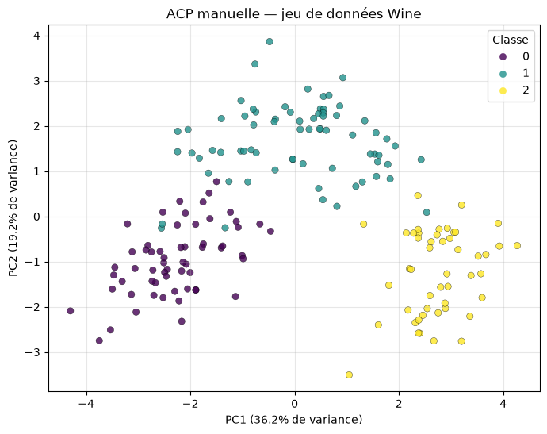

```python
# Étape 3 — Projection sur les deux premiers axes
W2 = eigenvectors[:, :2]
Z_manual = X_std_df.to_numpy() @ W2

projection_manual = pd.DataFrame(Z_manual, columns=["PC1", "PC2"], index=X.index)
projection_manual["classe"] = y.to_numpy()

fig, ax = plt.subplots(figsize=(8, 6))
scatter = ax.scatter(
    projection_manual["PC1"],
    projection_manual["PC2"],
    c=projection_manual["classe"],
    cmap="viridis",
    alpha=0.8,
    edgecolor="k",
    linewidth=0.3,
)
ax.set_xlabel(f"PC1 ({explained_variance_ratio[0]:.1%} de variance)")
ax.set_ylabel(f"PC2 ({explained_variance_ratio[1]:.1%} de variance)")
ax.set_title("ACP manuelle — jeu de données Wine")
ax.legend(*scatter.legend_elements(), title="Classe")
ax.grid(alpha=0.3)
plt.show()
```

### Exercice 3 — Validation avec `scikit-learn`

1. Reproduisez la standardisation avec `StandardScaler` puis l'ACP avec `PCA(n_components=2)`.
2. Comparez les variances expliquées à celles de votre implémentation.
3. Comparez les projections. Ne concluez pas à une erreur si un axe est inversé.
4. Calculez l'erreur absolue maximale entre les ratios de variance expliquée.
5. Expliquez pourquoi les résultats doivent être quasiment identiques malgré la différence éventuelle de signe.

```python
scaler = StandardScaler()
X_std_sklearn = scaler.fit_transform(X)

pca = PCA(n_components=2)
Z_sklearn = pca.fit_transform(X_std_sklearn)

manual_ratio = explained_variance_ratio[:2]
sklearn_ratio = pca.explained_variance_ratio_

print("Variance expliquée — manuel :", manual_ratio)
print("Variance expliquée — sklearn :", sklearn_ratio)
print("Écart absolu maximal :", np.max(np.abs(manual_ratio - sklearn_ratio)))

# Le signe des composantes étant arbitraire, on aligne chaque axe avant comparaison.
Z_manual_aligned = Z_manual.copy()
for j in range(2):
    correlation = np.corrcoef(Z_manual_aligned[:, j], Z_sklearn[:, j])[0, 1]
    if correlation < 0:
        Z_manual_aligned[:, j] *= -1

print("Écart maximal entre projections après alignement des signes :",
      np.max(np.abs(Z_manual_aligned - Z_sklearn)))

assert np.allclose(manual_ratio, sklearn_ratio, atol=1e-12)
```

```
Variance expliquée — manuel : [0.36198848 0.1920749 ]
Variance expliquée — sklearn : [0.36198848 0.1920749 ]
Écart absolu maximal : 8.326672684688674e-17
Écart maximal entre projections après alignement des signes : 0.012131624332429425
```

### Exercice 4 — Effet de la standardisation et choix du nombre de composantes

1. Réalisez une ACP à deux composantes sur les données simplement centrées, puis sur les données standardisées.
2. Comparez les projections et les ratios de variance expliquée.
3. Réalisez ensuite une ACP conservant toutes les composantes.
4. Tracez la variance expliquée individuelle et cumulée.
5. Déterminez le nombre minimal de composantes nécessaire pour conserver au moins 90 % puis 95 % de la variance.
6. Interprétez le résultat : une variance expliquée élevée garantit-elle une bonne séparation des classes ?

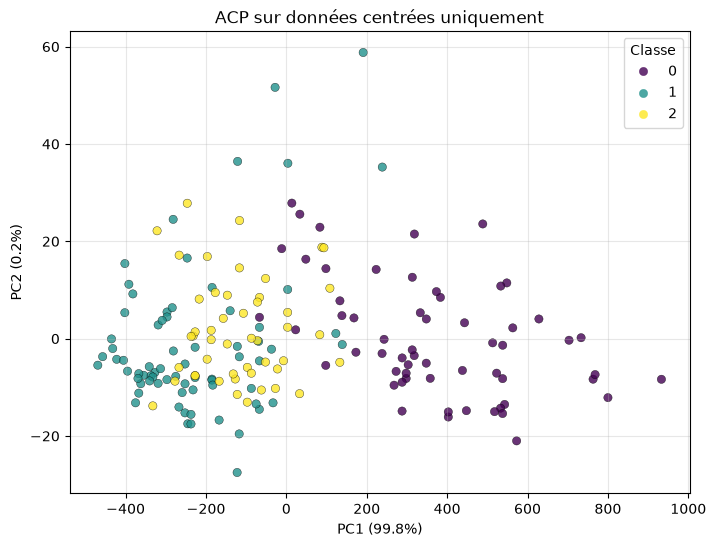

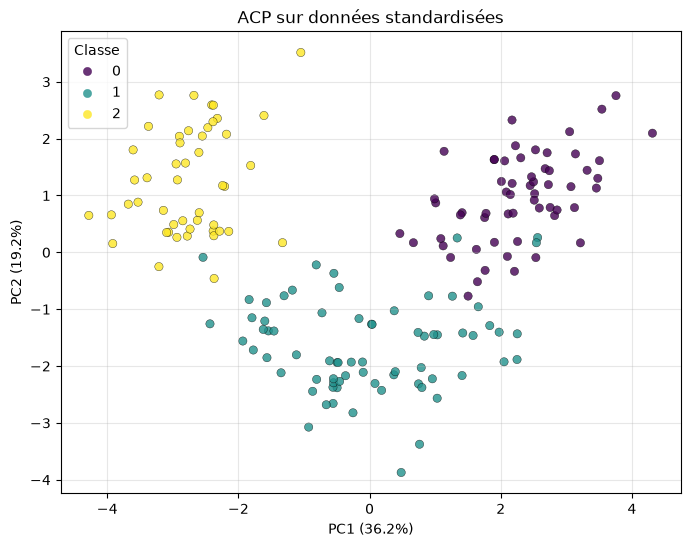

```
Ratios sans standardisation : [0.99809123 0.00173592]
Ratios avec standardisation : [0.36198848 0.1920749 ]
```

```python
# Comparaison sans/avec standardisation
pca_centered = PCA(n_components=2)
Z_centered = pca_centered.fit_transform(X)  # PCA centre automatiquement

pca_standardized = PCA(n_components=2)
Z_standardized = pca_standardized.fit_transform(X_std_sklearn)

fig, ax = plt.subplots(figsize=(8, 6))
scatter = ax.scatter(
    Z_centered[:, 0], Z_centered[:, 1],
    c=y, cmap="viridis", alpha=0.8, edgecolor="k", linewidth=0.3
)
ax.set_xlabel(f"PC1 ({pca_centered.explained_variance_ratio_[0]:.1%})")
ax.set_ylabel(f"PC2 ({pca_centered.explained_variance_ratio_[1]:.1%})")
ax.set_title("ACP sur données centrées uniquement")
ax.legend(*scatter.legend_elements(), title="Classe")
ax.grid(alpha=0.3)
plt.show()

fig, ax = plt.subplots(figsize=(8, 6))
scatter = ax.scatter(
    Z_standardized[:, 0], Z_standardized[:, 1],
    c=y, cmap="viridis", alpha=0.8, edgecolor="k", linewidth=0.3
)
ax.set_xlabel(f"PC1 ({pca_standardized.explained_variance_ratio_[0]:.1%})")
ax.set_ylabel(f"PC2 ({pca_standardized.explained_variance_ratio_[1]:.1%})")
ax.set_title("ACP sur données standardisées")
ax.legend(*scatter.legend_elements(), title="Classe")
ax.grid(alpha=0.3)
plt.show()

print("Ratios sans standardisation :", pca_centered.explained_variance_ratio_)
print("Ratios avec standardisation :", pca_standardized.explained_variance_ratio_)
```

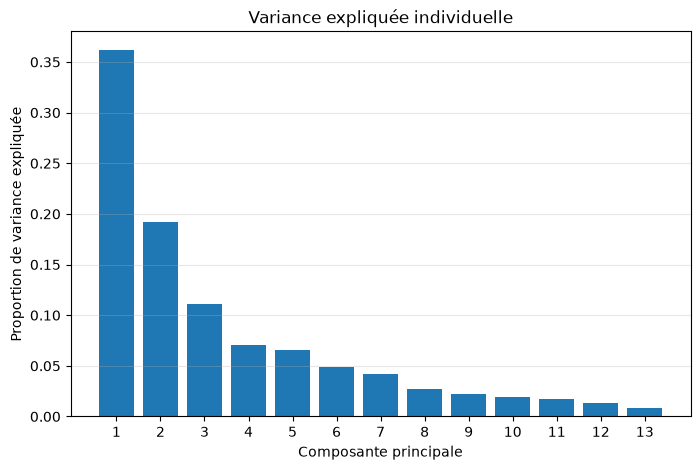

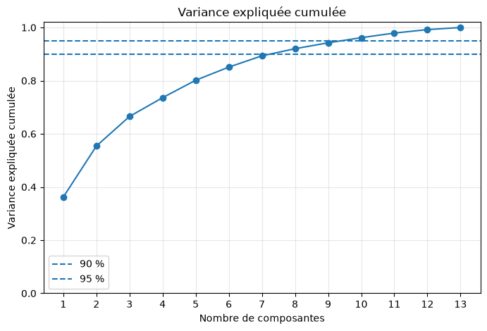

```
Nombre minimal de composantes pour 90 % : 8
Nombre minimal de composantes pour 95 % : 10
Une variance expliquée élevée mesure la conservation de la variance globale, mais ne garantit pas à elle seule une bonne séparation des classes.
```

```python
# Choix du nombre de composantes par variance expliquée
pca_full = PCA()
pca_full.fit(X_std_sklearn)

individual = pca_full.explained_variance_ratio_
cumulative = np.cumsum(individual)
components = np.arange(1, len(individual) + 1)

fig, ax = plt.subplots(figsize=(8, 5))
ax.bar(components, individual)
ax.set_xlabel("Composante principale")
ax.set_ylabel("Proportion de variance expliquée")
ax.set_title("Variance expliquée individuelle")
ax.set_xticks(components)
ax.grid(axis="y", alpha=0.3)
plt.show()

fig, ax = plt.subplots(figsize=(8, 5))
ax.plot(components, cumulative, marker="o")
ax.axhline(0.90, linestyle="--", label="90 %")
ax.axhline(0.95, linestyle="--", label="95 %")
ax.set_xlabel("Nombre de composantes")
ax.set_ylabel("Variance expliquée cumulée")
ax.set_title("Variance expliquée cumulée")
ax.set_xticks(components)
ax.set_ylim(0, 1.02)
ax.legend()
ax.grid(alpha=0.3)
plt.show()

n_90 = np.argmax(cumulative >= 0.90) + 1
n_95 = np.argmax(cumulative >= 0.95) + 1
print(f"Nombre minimal de composantes pour 90 % : {n_90}")
print(f"Nombre minimal de composantes pour 95 % : {n_95}")
print(
    "Une variance expliquée élevée mesure la conservation de la variance globale, "
    "mais ne garantit pas à elle seule une bonne séparation des classes."
)
```

## 3. t-SNE

t-SNE est une méthode non linéaire principalement destinée à la visualisation. Elle cherche à préserver les voisinages locaux en faisant correspondre des similarités dans l'espace original et dans l'espace projeté.

Contrairement à l'ACP :

- les axes t-SNE n'ont pas d'interprétation directe ;
- les distances globales et la taille relative des groupes sont peu fiables ;
- le résultat dépend de l'initialisation et des hyperparamètres, notamment la `perplexity` ;
- t-SNE ne fournit pas naturellement une transformation simple pour de nouvelles observations.

### Exercice 5 — Sensibilité de t-SNE

1. Appliquez t-SNE sur les données Wine standardisées avec `perplexity=5`, `30` et `50`.
2. Utilisez `init="pca"`, `learning_rate="auto"` et `random_state=RANDOM_STATE`.
3. Affichez séparément les trois projections.
4. Recommencez avec une autre graine aléatoire pour une valeur de perplexité.
5. Discutez la stabilité des voisinages et la prudence nécessaire pour interpréter les groupes.

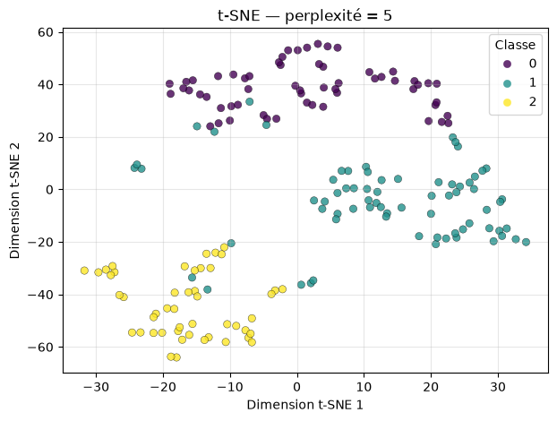

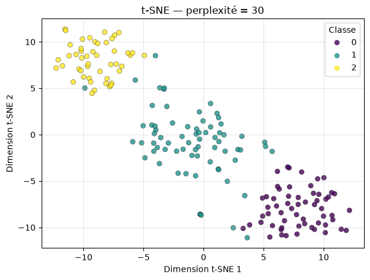

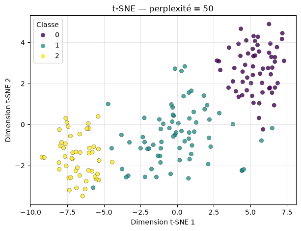

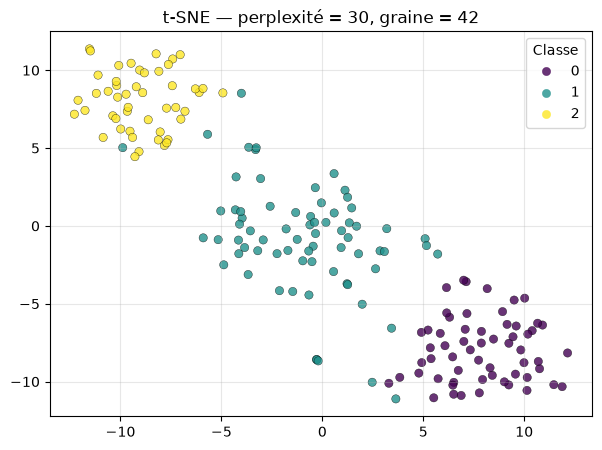

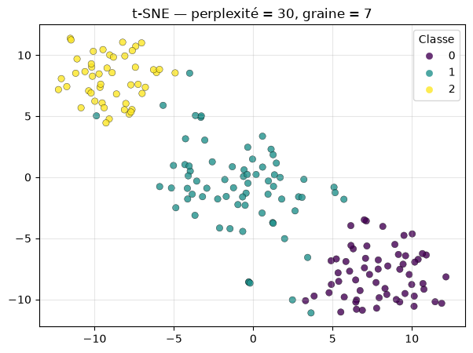

```
Interprétation : t-SNE préserve surtout les voisinages locaux. L'orientation, les distances entre groupes et leur taille apparente ne doivent pas être interprétées comme des quantités globales fiables.
```

```python
perplexities = [5, 30, 50]
tsne_results = {}

for perplexity in perplexities:
    tsne = TSNE(
        n_components=2,
        perplexity=perplexity,
        init="pca",
        learning_rate="auto",
        random_state=RANDOM_STATE,
        max_iter=1000,
    )
    Z_tsne = tsne.fit_transform(X_std_sklearn)
    tsne_results[perplexity] = Z_tsne

    fig, ax = plt.subplots(figsize=(7, 5))
    scatter = ax.scatter(
        Z_tsne[:, 0], Z_tsne[:, 1],
        c=y, cmap="viridis", alpha=0.8, edgecolor="k", linewidth=0.3
    )
    ax.set_xlabel("Dimension t-SNE 1")
    ax.set_ylabel("Dimension t-SNE 2")
    ax.set_title(f"t-SNE — perplexité = {perplexity}")
    ax.legend(*scatter.legend_elements(), title="Classe")
    ax.grid(alpha=0.3)
    plt.show()

# Sensibilité à la graine pour une perplexité donnée
perplexity_test = 30
for seed in [RANDOM_STATE, 7]:
    tsne = TSNE(
        n_components=2,
        perplexity=perplexity_test,
        init="pca",
        learning_rate="auto",
        random_state=seed,
        max_iter=1000,
    )
    Z_seed = tsne.fit_transform(X_std_sklearn)

    fig, ax = plt.subplots(figsize=(7, 5))
    scatter = ax.scatter(
        Z_seed[:, 0], Z_seed[:, 1],
        c=y, cmap="viridis", alpha=0.8, edgecolor="k", linewidth=0.3
    )
    ax.set_title(f"t-SNE — perplexité = {perplexity_test}, graine = {seed}")
    ax.legend(*scatter.legend_elements(), title="Classe")
    ax.grid(alpha=0.3)
    plt.show()

print(
    "Interprétation : t-SNE préserve surtout les voisinages locaux. "
    "L'orientation, les distances entre groupes et leur taille apparente "
    "ne doivent pas être interprétées comme des quantités globales fiables."
)
```

## 4. UMAP

UMAP construit un graphe de voisinage dans l'espace initial, puis cherche une représentation de faible dimension possédant une structure de voisinage similaire. Il est souvent plus rapide que t-SNE et permet de transformer de nouvelles observations.

Ses principaux hyperparamètres sont :

- `n_neighbors` : compromis entre structure locale et plus globale ;
- `min_dist` : compacité autorisée des groupes dans l'espace projeté ;
- `metric` : métrique utilisée dans l'espace initial.

### Exercice 6 — Influence des hyperparamètres UMAP

1. Importez `umap.umap_ as umap`.
2. Comparez les projections obtenues sur les données Wine standardisées pour `n_neighbors` égal à 5, 15 et 50.
3. Testez au moins deux valeurs de `min_dist`.
4. Comparez qualitativement les résultats à ceux de l'ACP et de t-SNE.
5. Expliquez pourquoi une meilleure séparation visuelle ne prouve pas automatiquement une meilleure représentation de la structure réelle.

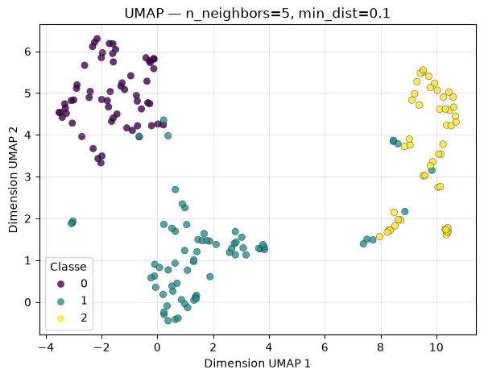

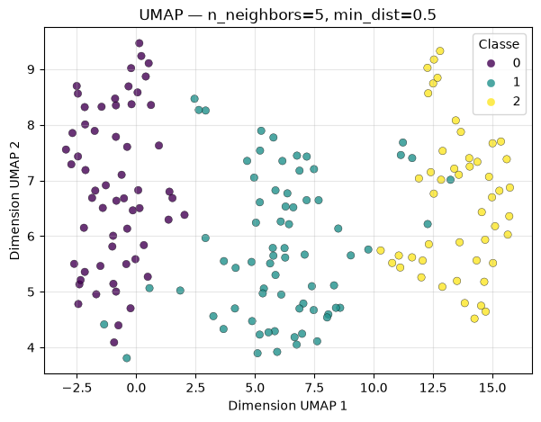

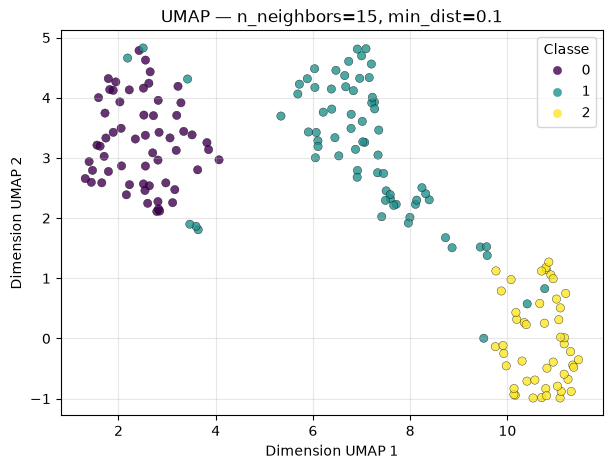

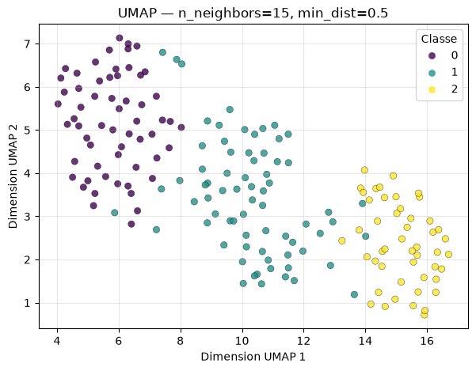

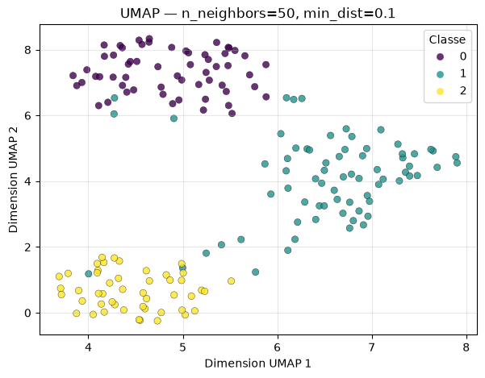

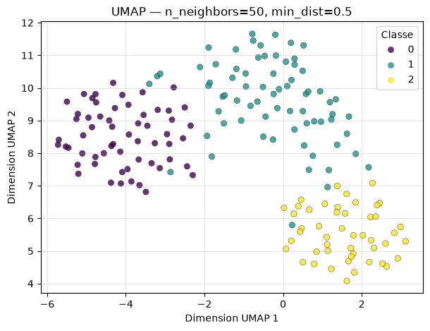

```
Une séparation visuelle plus nette ne prouve pas que toutes les distances ou la structure globale du jeu de données sont mieux conservées.
```

```python
try:
    import umap.umap_ as umap
except ImportError as exc:
    raise ImportError(
        "Le paquet 'umap-learn' est requis. Exécutez `%pip install -q umap-learn`, "
        "puis redémarrez le noyau."
    ) from exc

umap_results = {}
for n_neighbors in [5, 15, 50]:
    for min_dist in [0.1, 0.5]:
        reducer = umap.UMAP(
            n_components=2,
            n_neighbors=n_neighbors,
            min_dist=min_dist,
            metric="euclidean",
            random_state=RANDOM_STATE,
        )
        Z_umap = reducer.fit_transform(X_std_sklearn)
        umap_results[(n_neighbors, min_dist)] = Z_umap

        fig, ax = plt.subplots(figsize=(7, 5))
        scatter = ax.scatter(
            Z_umap[:, 0], Z_umap[:, 1],
            c=y, cmap="viridis", alpha=0.8, edgecolor="k", linewidth=0.3
        )
        ax.set_title(
            f"UMAP — n_neighbors={n_neighbors}, min_dist={min_dist}"
        )
        ax.set_xlabel("Dimension UMAP 1")
        ax.set_ylabel("Dimension UMAP 2")
        ax.legend(*scatter.legend_elements(), title="Classe")
        ax.grid(alpha=0.3)
        plt.show()

print(
    "Une séparation visuelle plus nette ne prouve pas que toutes les distances "
    "ou la structure globale du jeu de données sont mieux conservées."
)
```

# Partie II — Clustering

## 5. k-means : principe et hypothèses

k-means partitionne les observations en $k$ groupes en minimisant l'inertie intra-cluster :

$$ \sum_{i=1}^{n}\lVert x_i - \mu_{c(i)} \rVert^2. $$

L'algorithme alterne deux étapes : affectation de chaque point au centroïde le plus proche, puis recalcul des centroïdes. Il est sensible à l'initialisation et suppose implicitement des groupes relativement compacts, convexes et de tailles comparables.

### Évaluation

- **Inertie** : mesure de compacité, mais décroît mécaniquement lorsque $k$ augmente.
- **Silhouette** : métrique interne entre -1 et 1 combinant compacité et séparation.
- **ARI** et **NMI** : métriques externes utilisables lorsque des labels de référence sont disponibles. Elles ne supposent pas que les numéros de clusters correspondent aux numéros de classes.

## 6. Jeu de données Digits

Nous allons utiliser `sklearn.datasets.load_digits`. Le dataset contient des images 8 × 8 de chiffres manuscrits, soit 64 variables par observation.

### Exercice 7 — Préparation des données

1. Chargez `load_digits()`.
2. Affichez 15 images avec leurs labels.
3. Examinez les dimensions et la plage des valeurs de pixels.
4. Standardisez les variables avant l'ACP et k-means. Discutez néanmoins l'intérêt et les limites de cette standardisation pour des pixels partageant la même unité.

```
Dimensions des données : (1797, 64)
Forme d'une image : (8, 8)
Valeur minimale des pixels : 0.0
Valeur maximale des pixels : 16.0
Nombre de classes : 10
```

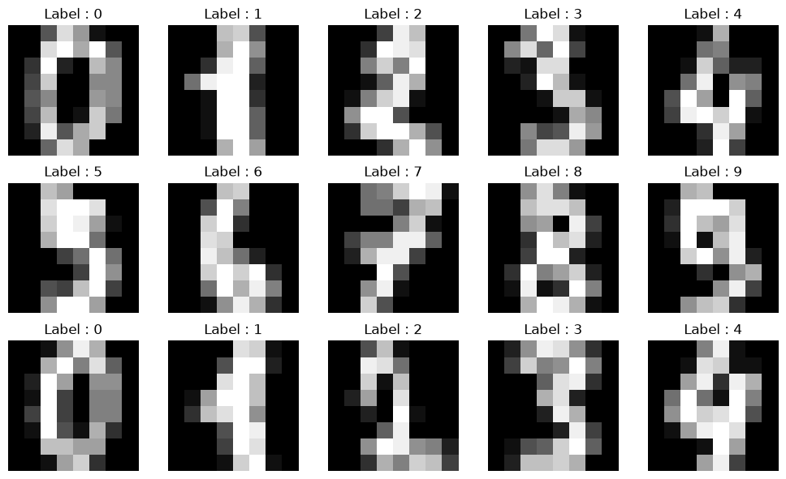

```
La standardisation évite qu'un pixel très variable domine les distances. Cependant, tous les pixels ont déjà la même unité et les pixels souvent nuls peuvent être fortement amplifiés ; son intérêt doit donc être évalué.
```

```python
digits = load_digits()
X_digits = pd.DataFrame(digits.data)
y_digits = pd.Series(digits.target, name="classe")

print(f"Dimensions des données : {X_digits.shape}")
print(f"Forme d'une image : {digits.images[0].shape}")
print(f"Valeur minimale des pixels : {X_digits.to_numpy().min()}")
print(f"Valeur maximale des pixels : {X_digits.to_numpy().max()}")
print(f"Nombre de classes : {y_digits.nunique()}")

fig, axes = plt.subplots(3, 5, figsize=(10, 6))
for ax, image, label in zip(axes.ravel(), digits.images[:15], y_digits.iloc[:15]):
    ax.imshow(image, cmap="gray")
    ax.set_title(f"Label : {label}")
    ax.axis("off")
plt.tight_layout()
plt.show()

digits_scaler = StandardScaler()
X_digits_std = digits_scaler.fit_transform(X_digits)

print(
    "La standardisation évite qu'un pixel très variable domine les distances. "
    "Cependant, tous les pixels ont déjà la même unité et les pixels souvent nuls "
    "peuvent être fortement amplifiés ; son intérêt doit donc être évalué."
)
```

### Exercice 8 — Choix de $k$ et clustering dans l'espace original

1. Pour $k$ allant de 2 à 15, ajustez un k-means avec `n_init=20` et `random_state=RANDOM_STATE`.
2. Tracez l'inertie et le score de silhouette en fonction de $k$ sur deux figures distinctes.
3. Proposez une valeur de $k$ sans utiliser les labels, puis comparez-la à la connaissance externe du nombre de chiffres.
4. Pour $k=10$, calculez l'ARI et la NMI avec les labels réels.
5. Expliquez pourquoi l'accuracy brute n'est pas une métrique appropriée sans réappariement des labels de clusters.

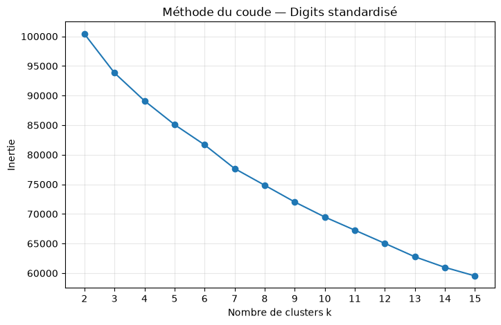

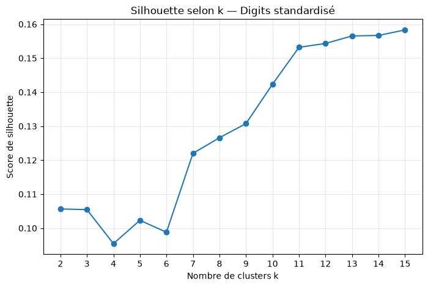

```
Meilleur k selon la silhouette dans l'intervalle testé : 15
Connaissance externe : le jeu contient 10 chiffres (0 à 9).
```

|  | espace | dimensions | inertie | silhouette | ARI | NMI |
| --- | --- | --- | --- | --- | --- | --- |
| 0 | Original standardisé | 64 | 69486.514474 | 0.142321 | 0.477962 | 0.631911 |

```
L'accuracy brute n'est pas adaptée car les numéros des clusters sont arbitraires. Un cluster numéroté 0 peut correspondre à n'importe quel chiffre réel.
```

```python
k_values = list(range(2, 16))
inertias = []
silhouettes = []

for k in k_values:
    model = KMeans(n_clusters=k, n_init=20, random_state=RANDOM_STATE)
    labels = model.fit_predict(X_digits_std)
    inertias.append(model.inertia_)
    silhouettes.append(silhouette_score(X_digits_std, labels))

fig, ax = plt.subplots(figsize=(8, 5))
ax.plot(k_values, inertias, marker="o")
ax.set_xlabel("Nombre de clusters k")
ax.set_ylabel("Inertie")
ax.set_title("Méthode du coude — Digits standardisé")
ax.set_xticks(k_values)
ax.grid(alpha=0.3)
plt.show()

fig, ax = plt.subplots(figsize=(8, 5))
ax.plot(k_values, silhouettes, marker="o")
ax.set_xlabel("Nombre de clusters k")
ax.set_ylabel("Score de silhouette")
ax.set_title("Silhouette selon k — Digits standardisé")
ax.set_xticks(k_values)
ax.grid(alpha=0.3)
plt.show()

best_k_silhouette = k_values[int(np.argmax(silhouettes))]
print(f"Meilleur k selon la silhouette dans l'intervalle testé : {best_k_silhouette}")
print("Connaissance externe : le jeu contient 10 chiffres (0 à 9).")

kmeans_original = KMeans(n_clusters=10, n_init=20, random_state=RANDOM_STATE)
labels_original = kmeans_original.fit_predict(X_digits_std)

metrics_original = {
    "espace": "Original standardisé",
    "dimensions": X_digits_std.shape[1],
    "inertie": kmeans_original.inertia_,
    "silhouette": silhouette_score(X_digits_std, labels_original),
    "ARI": adjusted_rand_score(y_digits, labels_original),
    "NMI": normalized_mutual_info_score(y_digits, labels_original),
}
display(pd.DataFrame([metrics_original]))

print(
    "L'accuracy brute n'est pas adaptée car les numéros des clusters sont arbitraires. "
    "Un cluster numéroté 0 peut correspondre à n'importe quel chiffre réel."
)
```

### Exercice 9 — PCA puis k-means

1. Standardisez les données Digits.
2. Appliquez une ACP en conservant 90 % de la variance (`n_components=0.90`).
3. Indiquez le nombre de dimensions conservées.
4. Appliquez k-means avec $k=10$ dans cet espace réduit.
5. Comparez temps d'ajustement, inertie, silhouette, ARI et NMI avec le clustering dans l'espace original.
6. Pour la visualisation seulement, projetez les données sur les deux premières composantes et colorez-les selon les clusters.
7. Discutez pourquoi l'espace utilisé pour visualiser ne doit pas nécessairement être celui utilisé pour entraîner k-means.

```
Nombre de dimensions conservées par la PCA à 90 % : 31
```

|  | espace | dimensions | temps_s | inertie | silhouette | ARI | NMI |
| --- | --- | --- | --- | --- | --- | --- | --- |
| 0 | Original standardisé | 64 | 0.092888 | 69486.514474 | 0.142321 | 0.477962 | 0.631911 |
| 1 | PCA 90 % | 31 | 0.178776 | 58609.002905 | 0.173373 | 0.462510 | 0.621894 |

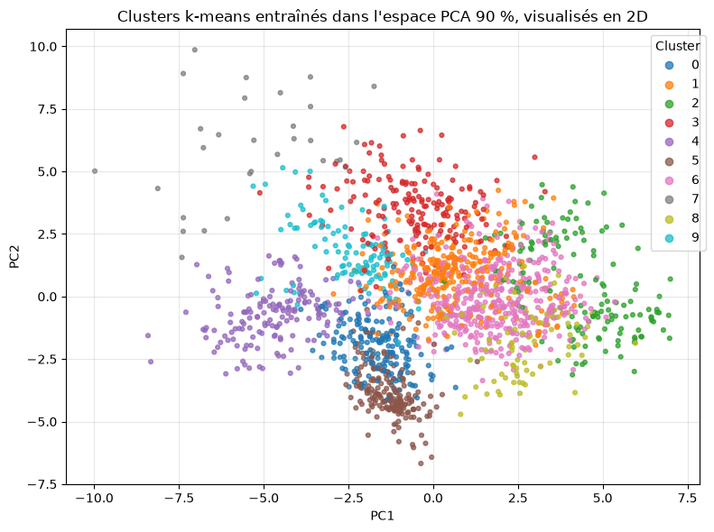

```
La projection 2D perd davantage d'information que l'espace PCA à 90 %. Elle sert à visualiser les clusters, pas nécessairement à les entraîner.
```

```python
import time

# Mesure du temps dans l'espace original standardisé
start = time.perf_counter()
kmeans_original_timed = KMeans(n_clusters=10, n_init=20, random_state=RANDOM_STATE)
labels_original_timed = kmeans_original_timed.fit_predict(X_digits_std)
time_original = time.perf_counter() - start

# PCA conservant 90 % de la variance
pca_digits_90 = PCA(n_components=0.90, svd_solver="full")
X_digits_pca90 = pca_digits_90.fit_transform(X_digits_std)
print(f"Nombre de dimensions conservées par la PCA à 90 % : {X_digits_pca90.shape[1]}")

start = time.perf_counter()
kmeans_pca = KMeans(n_clusters=10, n_init=20, random_state=RANDOM_STATE)
labels_pca = kmeans_pca.fit_predict(X_digits_pca90)
time_pca = time.perf_counter() - start

comparison_clustering = pd.DataFrame([
    {
        "espace": "Original standardisé",
        "dimensions": X_digits_std.shape[1],
        "temps_s": time_original,
        "inertie": kmeans_original_timed.inertia_,
        "silhouette": silhouette_score(X_digits_std, labels_original_timed),
        "ARI": adjusted_rand_score(y_digits, labels_original_timed),
        "NMI": normalized_mutual_info_score(y_digits, labels_original_timed),
    },
    {
        "espace": "PCA 90 %",
        "dimensions": X_digits_pca90.shape[1],
        "temps_s": time_pca,
        "inertie": kmeans_pca.inertia_,
        "silhouette": silhouette_score(X_digits_pca90, labels_pca),
        "ARI": adjusted_rand_score(y_digits, labels_pca),
        "NMI": normalized_mutual_info_score(y_digits, labels_pca),
    },
])
display(comparison_clustering)

# Projection 2D réservée à la visualisation
pca_digits_2 = PCA(n_components=2)
X_digits_pca2 = pca_digits_2.fit_transform(X_digits_std)

fig, ax = plt.subplots(figsize=(8, 6))
scatter = ax.scatter(
    X_digits_pca2[:, 0],
    X_digits_pca2[:, 1],
    c=labels_pca,
    cmap="tab10",
    s=12,
    alpha=0.75,
)
ax.set_xlabel("PC1")
ax.set_ylabel("PC2")
ax.set_title("Clusters k-means entraînés dans l'espace PCA 90 %, visualisés en 2D")
ax.legend(*scatter.legend_elements(), title="Cluster", bbox_to_anchor=(1.02, 1))
ax.grid(alpha=0.3)
plt.tight_layout()
plt.show()

print(
    "La projection 2D perd davantage d'information que l'espace PCA à 90 %. "
    "Elle sert à visualiser les clusters, pas nécessairement à les entraîner."
)
```

### Exercice 10 — UMAP puis k-means : protocole critique

1. Construisez une représentation UMAP à 2 dimensions, puis appliquez k-means avec $k=10$.
2. Calculez silhouette, ARI et NMI.
3. Comparez avec l'espace original et l'espace PCA.
4. Répétez l'expérience pour plusieurs graines aléatoires et présentez moyenne et écart-type des scores.
5. Discutez le risque méthodologique consistant à choisir les hyperparamètres UMAP en observant directement les labels réels.

```python
try:
    import umap.umap_ as umap
except ImportError as exc:
    raise ImportError(
        "Le paquet 'umap-learn' est requis. Exécutez `%pip install -q umap-learn`, "
        "puis redémarrez le noyau."
    ) from exc

seeds = [0, 7, 21, 42, 99]
umap_scores = []

for seed in seeds:
    reducer_10d = umap.UMAP(
        n_components=2,
        n_neighbors=15,
        min_dist=0.1,
        metric="euclidean",
        random_state=seed,
    )
    X_digits_umap10 = reducer_10d.fit_transform(X_digits_std)

    kmeans_umap = KMeans(n_clusters=10, n_init=20, random_state=seed)
    labels_umap = kmeans_umap.fit_predict(X_digits_umap10)

    umap_scores.append({
        "graine": seed,
        "silhouette": silhouette_score(X_digits_umap10, labels_umap),
        "ARI": adjusted_rand_score(y_digits, labels_umap),
        "NMI": normalized_mutual_info_score(y_digits, labels_umap),
    })

umap_scores_df = pd.DataFrame(umap_scores)
display(umap_scores_df)

summary_umap = umap_scores_df[["silhouette", "ARI", "NMI"]].agg(["mean", "std"]).T
summary_umap.columns = ["moyenne", "ecart_type"]
print("Résumé des scores UMAP + k-means :")
display(summary_umap)

comparison_final = comparison_clustering[
    ["espace", "dimensions", "silhouette", "ARI", "NMI"]
].copy()
comparison_final = pd.concat([
    comparison_final,
    pd.DataFrame([{
        "espace": "UMAP 10D + k-means (moyenne)",
        "dimensions": 10,
        "silhouette": umap_scores_df["silhouette"].mean(),
        "ARI": umap_scores_df["ARI"].mean(),
        "NMI": umap_scores_df["NMI"].mean(),
    }])
], ignore_index=True)
display(comparison_final)

print(
    "Les labels réels ne doivent pas servir à choisir les hyperparamètres UMAP "
    "dans un protocole réellement non supervisé : cela introduirait une fuite "
    "d'information et surestimerait les performances de généralisation."
)
```

|  | graine | silhouette | ARI | NMI |
| --- | --- | --- | --- | --- |
| 0 | 0 | 0.711313 | 0.860993 | 0.889963 |
| 1 | 7 | 0.699364 | 0.864652 | 0.888251 |
| 2 | 21 | 0.712299 | 0.864616 | 0.894378 |
| 3 | 42 | 0.708280 | 0.868376 | 0.894882 |
| 4 | 99 | 0.704863 | 0.871233 | 0.896934 |

```
Résumé des scores UMAP + k-means :
```

|  | moyenne | ecart_type |
| --- | --- | --- |
| silhouette | 0.707224 | 0.005266 |
| ARI | 0.865974 | 0.003932 |
| NMI | 0.892882 | 0.003627 |

[output not shown]

```
Les labels réels ne doivent pas servir à choisir les hyperparamètres UMAP dans un protocole réellement non supervisé : cela introduirait une fuite d'information et surestimerait les performances de généralisation.
```